# Image Classification

```python
import keras
```

```python
class_names = ['shoe', 'lipstick', 'bag', 'nailpolish', 'necklace',
               'earrings', 'watch', 'ring', 'bracelet']
```

### Pre-Processing

Pre process this data. This uses ImageDataGenerator and data augmentation features to load the dataset. Augmentation was applied to increase size and variety of our dataset since it was relatively small.

```python
from keras.preprocessing.image import ImageDataGenerator

# Your code here ...
train_dir = 'soa/train_folder'
validation_dir = 'soa/test_folder'

# All images will be rescaled by 1./255
train_datagen = ImageDataGenerator(rescale=1./255, rotation_range=20, zoom_range=0.15, width_shift_range=0.2, height_shift_range=0.2, shear_range=0.15, horizontal_flip=True)
test_datagen = ImageDataGenerator(rescale=1./255, rotation_range=20, zoom_range=0.15, width_shift_range=0.2, height_shift_range=0.2, shear_range=0.15, horizontal_flip=True)

train_generator = train_datagen.flow_from_directory(
        # This is the target directory
        train_dir,
        # All images will be resized to 150x150
        target_size=(32, 32),
        batch_size=20,
        # Since we use binary_crossentropy loss, we need binary labels
        class_mode='categorical')

validation_generator = test_datagen.flow_from_directory(
        validation_dir,
        target_size=(32, 32),
        batch_size=20,
        class_mode='categorical')
```

```
Found 1644 images belonging to 9 classes.
Found 705 images belonging to 9 classes.
```

Store the raw images and true labels from a batch. This is used for testing later and to verify that the data was loaded correctly. Some of the images have augmentation applied from the Image Geneartor processing.

```
4 necklace
```

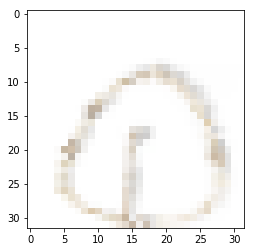

```
0 shoe
```

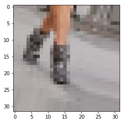

```
0 shoe
```

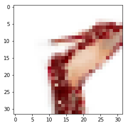

```
2 bag
```

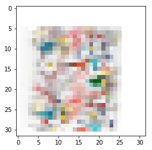

```
2 bag
```

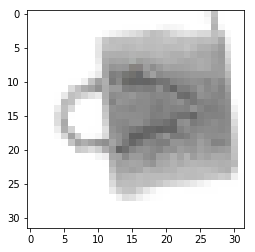

```
1 lipstick
```

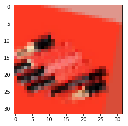

```python
train_images, train_labels = train_generator.next()

train_labels_converted = []
for i in train_labels:
    train_labels_converted.append(np.argmax(i))

for i in range(0,3):
    image = train_images[i]
    label = train_labels_converted[i]
    print (label, class_names[label])
    plt.imshow(image)
    plt.show()

test_images, test_labels = train_generator.next()

test_labels_converted = []
for i in test_labels:
    test_labels_converted.append(np.argmax(i))

for i in range(0,3):
    image = test_images[i]
    label = test_labels_converted[i]
    print (label, class_names[label])
    plt.imshow(image)
    plt.show()
```

### MLP vs CNN Models

#### MLP

Build MLP model. [Reference](https://www.peculiar-coding-endeavours.com/2018/mlp_vs_cnn/)

```python
from keras import layers
from keras import models

model_mlp = models.Sequential()
model_mlp.add(layers.Flatten(input_shape = (32, 32, 3)))
model_mlp.add(layers.Dense(128, activation = 'relu'))
model_mlp.add(layers.Dropout(0.5))
model_mlp.add(layers.Dense(128, activation = 'relu'))
model_mlp.add(layers.Dropout(0.5))
model_mlp.add(layers.Dense(9, activation = 'softmax'))
```

```python
model_mlp.summary()
```

```
Model: "sequential_19"
_________________________________________________________________
Layer (type)                 Output Shape              Param #
=================================================================
flatten_9 (Flatten)          (None, 3072)              0
_________________________________________________________________
dense_38 (Dense)             (None, 128)               393344
_________________________________________________________________
dropout_29 (Dropout)         (None, 128)               0
_________________________________________________________________
dense_39 (Dense)             (None, 128)               16512
_________________________________________________________________
dropout_30 (Dropout)         (None, 128)               0
_________________________________________________________________
dense_40 (Dense)             (None, 9)                 1161
=================================================================
Total params: 411,017
Trainable params: 411,017
Non-trainable params: 0
_________________________________________________________________
```

```python
model_mlp.compile(loss='categorical_crossentropy',
              optimizer='adam',
              metrics=['acc'])
```

```python
history_mlp = model_mlp.fit_generator(
      train_generator,
      steps_per_epoch=100,
      epochs=100,
      validation_data=validation_generator,
      validation_steps=50)
```

Plot accuracy and loss curves. Reference HW7.

[figure not shown]

[figure not shown]

```python
import matplotlib.pyplot as plt
%matplotlib inline

acc = history_mlp.history['acc']
val_acc = history_mlp.history['val_acc']
loss = history_mlp.history['loss']
val_loss = history_mlp.history['val_loss']

epochs = range(len(acc))

plt.plot(epochs, acc, 'bo', label='Training acc')
plt.plot(epochs, val_acc, 'b', label='Validation acc')
plt.title('Training and validation accuracy')
plt.legend()

plt.figure()

plt.plot(epochs, loss, 'bo', label='Training loss')
plt.plot(epochs, val_loss, 'b', label='Validation loss')
plt.title('Training and validation loss')
plt.legend()

plt.show()
```

#### CNN

Build the CNN model. Reference from HW7 and lab, but with changes to activiations and dropout.

```python
from keras import layers
from keras import models

# sequential
model = models.Sequential()

# layer 1 - convo2D specify input
model.add(layers.Conv2D(32, (3, 3), activation='relu',
                        input_shape=(32, 32, 3)))
# 32 is image size from above, (3, 3) is deimensions of kernel

# layer 2 - convo2D no input shape
model.add(layers.Conv2D(32, (3, 3), activation='relu'))

# layer 3 - maxpooling2D
model.add(layers.MaxPooling2D((2, 2)))

# layer 4 - dropout
model.add(layers.Dropout(rate = 0.5))

# layer 5 - flatten
model.add(layers.Flatten())

# layer 6 - dense
model.add(layers.Dense(128, activation='relu'))

# layer 7 - dropout
model.add(layers.Dropout(rate = 0.5))

# layer 8 - dense
model.add(layers.Dense(9, activation='softmax'))
```

```python
model.summary()
```

```
Model: "sequential_20"
_________________________________________________________________
Layer (type)                 Output Shape              Param #
=================================================================
conv2d_13 (Conv2D)           (None, 30, 30, 32)        896
_________________________________________________________________
conv2d_14 (Conv2D)           (None, 28, 28, 32)        9248
_________________________________________________________________
max_pooling2d_7 (MaxPooling2 (None, 14, 14, 32)        0
_________________________________________________________________
dropout_31 (Dropout)         (None, 14, 14, 32)        0
_________________________________________________________________
flatten_10 (Flatten)         (None, 6272)              0
_________________________________________________________________
dense_41 (Dense)             (None, 128)               802944
_________________________________________________________________
dropout_32 (Dropout)         (None, 128)               0
_________________________________________________________________
dense_42 (Dense)             (None, 9)                 1161
=================================================================
Total params: 814,249
Trainable params: 814,249
Non-trainable params: 0
_________________________________________________________________
```

```python
model.compile(loss='categorical_crossentropy',
              optimizer='adam',
              metrics=['acc'])

history = model.fit_generator(
      train_generator,
      steps_per_epoch=100,
      epochs=100,
      validation_data=validation_generator,
      validation_steps=50)
```

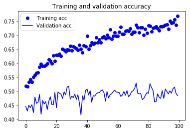

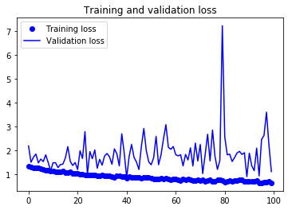

```python
import matplotlib.pyplot as plt
%matplotlib inline

acc = history.history['acc']
val_acc = history.history['val_acc']
loss = history.history['loss']
val_loss = history.history['val_loss']

epochs = range(len(acc))

plt.plot(epochs, acc, 'bo', label='Training acc')
plt.plot(epochs, val_acc, 'b', label='Validation acc')
plt.title('Training and validation accuracy')
plt.legend()

plt.figure()

plt.plot(epochs, loss, 'bo', label='Training loss')
plt.plot(epochs, val_loss, 'b', label='Validation loss')
plt.title('Training and validation loss')
plt.legend()

plt.show()
```

Use model to make predictions on test images. Output is an array of probabilities with index corresponding to the class the image is predicted to belong to. An example is shown.

```python
predictions = model.predict(test_images)
```

```python
print(predictions[0])
```

```
[5.3297401e-05 4.1360646e-08 1.3792545e-04 4.3590745e-08 3.7708441e-09
 9.9926072e-01 1.8003412e-09 5.4794486e-04 1.6794163e-08]
```

```python
np.argmax(test_labels[0])
```

```
1
```

```python
def plot_image(i, predictions_array, true_labels, imgs):
    predictions_array, true_label, img = predictions_array, true_labels[i], imgs[i]

    plt.grid(False)
    plt.xticks([])
    plt.yticks([])

    plt.imshow(img, cmap=plt.cm.binary)

    predicted_label = np.argmax(predictions_array)
    if predicted_label == true_label:
        color = 'green'
    else:
        color = 'red'

    plt.xlabel("{} {:2.0f}% ({})".format(class_names[predicted_label],
                                100*np.max(predictions_array),
                                class_names[true_label]),
                                color=color)
```

```python
def plot_value_array(i, predictions_array, true_labels):
    predictions_array, true_label = predictions_array, true_labels[i]
    plt.grid(False)
    plt.xticks(range(9))
    plt.yticks([])
    thisplot = plt.bar(range(9), predictions_array, color="#777777")
    plt.ylim([0, 1])
    predicted_label = np.argmax(predictions_array)

    thisplot[predicted_label].set_color('red')
    thisplot[true_label].set_color('green')
```

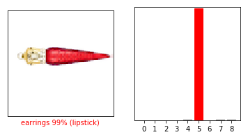

```python
import numpy as np
i = 4
plt.figure(figsize=(6,3))
plt.subplot(1,2,1)
plot_image(i, predictions[i], test_labels_converted, test_images)
plt.subplot(1,2,2)
plot_value_array(i, predictions[i],  test_labels_converted)
plt.show()
```

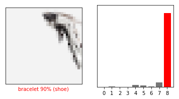

```python
import numpy as np
i = 9
plt.figure(figsize=(6,3))
plt.subplot(1,2,1)
plot_image(i, predictions[i], test_labels_converted, test_images)
plt.subplot(1,2,2)
plot_value_array(i, predictions[i],  test_labels_converted)
plt.show()
```